# pastclim overview

# Install the library

`pastclim` is on CRAN, and the easiest way to install it is with:

```r
install.packages("pastclim")
```

If you want the latest development version, you can get it from GitHub. To install from GitHub, you will need to use `devtools`; if you haven’t done so already, install it from CRAN with `install.packages("devtools")`. Also, note that the `dev` version of `pastclim` tracks changes in the `dev` version of `terra`, so you will need to upgrade to both:

```r
install.packages("terra", repos = "https://rspatial.r-universe.dev")
devtools::install_github("EvolEcolGroup/pastclim", ref = "dev")
```

On its dedicated [website](https://evolecolgroup.github.io/pastclim/), you can find Articles giving you a step-by-step [overview of the package](https://evolecolgroup.github.io/pastclim/articles/a0_pastclim_overview.html), and a [cheatsheet](https://evolecolgroup.github.io/pastclim/pastclim_cheatsheet.pdf). There is also a [version](https://evolecolgroup.github.io/pastclim/dev/) of the site updated for the `dev` version (on the top left, the version number is in red, and will be in the format x.x.x.9xxx, indicating it is a development version).

If you want to build the vignette directly in `R` when installing `pastclim` from GitHub, you can :

```r
devtools::install_github("EvolEcolGroup/pastclim",
  ref = "dev",
  build_vignettes = TRUE
)
```

And read it directly in R with:

```r
vignette("pastclim_overview", package = "pastclim")
```

Depending on the operating system you use, you might need additional packages to build a vignette.

# Download the data

You will need to download climatic reconstructions before being able to do any real work with `pastclim`. Pastclim currently includes data from Beyer et al 2020 (*Beyer2020*, a reconstruction of climate based on the HadCM3 model for the last 120k years), Krapp et al 2021 (*Krapp2021*, which covers the last 800k years with a statistical emulator of HadCM3), Barreto et al 2023 (*Barreto2023*), covering the last 5M years using the PALEO-PGEM emulator), the CHELSA-TraCE21k, covering the last 21k years at high spatial and temporal resolution (*CHELSA_trace21k_0.5m_vsi*), the HYDE3.3 database of land use reconstructions for the last 10k years (*HYDE_3.3_baseline*) the *paleoclim* dataset, a selected few time steps over the last 120k years at various resolutions (*paleoclim_RESm*), and the WorldClim and CHELSA data (*WorldClim_2.1_* and *CHELSA_2.1_*, present, and future projections with a number of models and emission scenarios). More information on each of these datasets can be found [here](https://evolecolgroup.github.io/pastclim/articles/a1_available_datasets.html), or using the help page for a given dataset. For detailed instructions on how to use the WorldClim and CHELSA datasets for present and future reconstructions can be found in [this article](https://evolecolgroup.github.io/pastclim/articles/a3_pastclim_present_and_future.html) There are also instructions on how to build and use [custom datasets](https://evolecolgroup.github.io/pastclim/articles/a2_custom_datasets.html), but you will need some familiarity with handling `netcdf` files.

A list of all datasets available can be obtained by typing:

```r
library(pastclim)
get_available_datasets()
```

[output not shown]

Please be aware that using any dataset made available to `pastclim` will require to cite both `pastclim` as well as the original publication presenting the dataset. The reference to cite for `pastclim` can be obtained by typing

```r
citation("pastclim")
```

```
#>
#>   Leonardi M, Hallet EY, Beyer R, Krapp M, Manica A (2023). "pastclim
#>   1.2: an R package to easily access and use paleoclimatic
#>   reconstructions." _Ecography_, *2023*, e06481. doi:10.1111/ecog.06481
#>   <https://doi.org/10.1111/ecog.06481>.
#>
#> A BibTeX entry for LaTeX users is
#>
#>   @Article{pastclim-article,
#>     title = {pastclim 1.2: an R package to easily access and use paleoclimatic reconstructions},
#>     author = {Michela Leonardi and Emily Y. Hallet and Robert Beyer and Mario Krapp and Andrea Manica},
#>     journal = {Ecography},
#>     year = {2023},
#>     volume = {2023},
#>     pages = {e06481},
#>     publisher = {Wiley},
#>     doi = {10.1111/ecog.06481},
#>   }
```

while the reference associated to any dataset of choice (in this case “Beyer2020”) is displayed together with the general information on that dataset through the command:

```r
help("Beyer2020")
```

```
#> Documentation for the Beyer2020 dataset
#>
#> Description:
#>
#>      This dataset covers the last 120k years, at intervals of 1/2 k
#>      years, and a resolution of 0.5 degrees in latitude and longitude.
#>
#> Details:
#>
#>      IMPORTANT: If you use this dataset, make sure to cite the original
#>      publication:
#>
#>      Beyer, R.M., Krapp, M. & Manica, A. High-resolution terrestrial
#>      climate, bioclimate and vegetation for the last 120,000 years. Sci
#>      Data 7, 236 (2020). doi:10.1038/s41597-020-0552-1
#>
#>      The version included in 'pastclim' has the ice sheets masked, as
#>      well as internal seas (Black and Caspian Sea) removed. The latter
#>      are based on:
#>
#>
#>
#>      As there is no reconstruction of their depth through time, modern
#>      outlines were used for all time steps.
#>
#>      Also, for bio15, the coefficient of variation was computed after
#>      adding one to monthly estimates, and it was multiplied by 100
#>      following <https://pubs.usgs.gov/ds/691/ds691.pdf>
#>
#>      Changelog
#>
#>      v1.1.0 Added monthly variables. Files can be downloaded from:
#>
#>      v1.0.0 Remove ice sheets and internal seas, and use correct
#>      formula for bio15. Files can be downloaded from:
#>      doi:10.6084/m9.figshare.19723405.v1
```

For the datasets available in `pastclim`, there are functions that help you download the data and choose the variables. When you start `pastclim` for the first time, you will need to set the path where reconstructions are stored using `set_data_path`. By default, the package data path will be used:

```r
library(pastclim)
set_data_path()
```

```
#> The data_path will be set to /home/andrea/.local/share/R/pastclim.
#> A copy of the Example dataset will be copied there.
#> This path will be saved by pastclim for future use.
#> Proceed?
#>
#> 1: Yes
#> 2: No
```

Press 1 if you are happy with the offered choices, and `pastclim` will remember your data path in future sessions. Note that your data path will look different than in this example, as it depends on your user name and operating system.

If you prefer using a custom path (e.g. in “~/my_reconstructions”), it can be set with:

```r
set_data_path(path_to_nc = "~/my_reconstructions")
```

The package includes a small dataset, *Example*, that we will use in this vignette but is not suitable for running real analyses; the real datasets are large (from 100s of Mb to a few Gb), and you will need to specify what you want to download (see below).

Let us start by inspecting the *Example* dataset. We can get a list of variables available for this dataset with:

```r
get_vars_for_dataset(dataset = "Example")
```

```
#> [1] "bio01" "bio10" "bio12" "biome"
```

and the available time steps can be obtained with:

```r
get_time_bp_steps(dataset = "Example")
```

```
#> [1] -20000 -15000 -10000  -5000      0
```

We can also query the resolution of this dataset:

```r
get_resolution(dataset = "Example")
```

```
#> [1] 1 1
```

so, the *Example” dataset only has a resolution of 1x1 degree.

For *Beyer2020* and *Krapp2021*, you can get a list of available variables for each dataset with:

```r
get_vars_for_dataset(dataset = "Beyer2020")
```

```
#>  [1] "bio01"    "bio04"    "bio05"    "bio06"    "bio07"    "bio08"
#>  [7] "bio09"    "bio10"    "bio11"    "bio12"    "bio13"    "bio14"
#> [13] "bio15"    "bio16"    "bio17"    "bio18"    "bio19"    "npp"
#> [19] "lai"      "biome"    "altitude" "rugosity"
```

and

```r
get_vars_for_dataset(dataset = "Krapp2021")
```

```
#>  [1] "bio01"    "bio04"    "bio05"    "bio06"    "bio07"    "bio08"
#>  [7] "bio09"    "bio10"    "bio11"    "bio12"    "bio13"    "bio14"
#> [13] "bio15"    "bio16"    "bio17"    "bio18"    "bio19"    "npp"
#> [19] "biome"    "lai"      "altitude" "rugosity"
```

Note that, by default, only annual variables are shown. To see the available monthly variables, simply use:

```r
get_vars_for_dataset(dataset = "Beyer2020", annual = FALSE, monthly = TRUE)
```

```
#>  [1] "temperature_01"       "temperature_02"       "temperature_03"
#>  [4] "temperature_04"       "temperature_05"       "temperature_06"
#>  [7] "temperature_07"       "temperature_08"       "temperature_09"
#> [10] "temperature_10"       "temperature_11"       "temperature_12"
#> [13] "precipitation_01"     "precipitation_02"     "precipitation_03"
#> [16] "precipitation_04"     "precipitation_05"     "precipitation_06"
#> [19] "precipitation_07"     "precipitation_08"     "precipitation_09"
#> [22] "precipitation_10"     "precipitation_11"     "precipitation_12"
#> [25] "cloudiness_01"        "cloudiness_02"        "cloudiness_03"
#> [28] "cloudiness_04"        "cloudiness_05"        "cloudiness_06"
#> [31] "cloudiness_07"        "cloudiness_08"        "cloudiness_09"
#> [34] "cloudiness_10"        "cloudiness_11"        "cloudiness_12"
#> [37] "relative_humidity_01" "relative_humidity_02" "relative_humidity_03"
#> [40] "relative_humidity_04" "relative_humidity_05" "relative_humidity_06"
#> [43] "relative_humidity_07" "relative_humidity_08" "relative_humidity_09"
#> [46] "relative_humidity_10" "relative_humidity_11" "relative_humidity_12"
#> [49] "wind_speed_01"        "wind_speed_02"        "wind_speed_03"
#> [52] "wind_speed_04"        "wind_speed_05"        "wind_speed_06"
#> [55] "wind_speed_07"        "wind_speed_08"        "wind_speed_09"
#> [58] "wind_speed_10"        "wind_speed_11"        "wind_speed_12"
#> [61] "mo_npp_01"            "mo_npp_02"            "mo_npp_03"
#> [64] "mo_npp_04"            "mo_npp_05"            "mo_npp_06"
#> [67] "mo_npp_07"            "mo_npp_08"            "mo_npp_09"
#> [70] "mo_npp_10"            "mo_npp_11"            "mo_npp_12"
```

For monthly variables, months are coded as “_xx” at the end of the variable names; e.g. “temperature_02” is the mean monthly temperature for February. A more thorough description of each variable (including the units) can be obtained with:

```r
get_vars_for_dataset(dataset = "Example", details = TRUE)
```

```
#>   variable                           long_name           units
#> 1    bio01             annual mean temperature degrees Celsius
#> 2    bio10 mean temperature of warmest quarter degrees Celsius
#> 3    bio12                annual precipitation     mm per year
#> 4    biome                 biome (from BIOME4)
```

You will not be able to get the available time steps until you download the dataset. `pastclim` offers an interface to download the necessary files into your data path.

To inspect which datasets and variables have already been downloaded in the data path, we can use:

```r
get_downloaded_datasets()
```

```
#> $Example
#> [1] "bio01" "bio10" "bio12" "biome"
```

Let’s now download *bio01* and *bio05* for the *Beyer2020* dataset (this operation might take several minutes, as the datasets are large; `R` will pause until the download is complete):

```r
download_dataset(dataset = "Beyer2020", bio_variables = c("bio01", "bio05"))
```

Note that multiple variables can be packed together into a single file, so `get_downloaded_datasets()` might list more variables than the ones that we chose to download (it depends on the dataset).

When upgrading `pastclim`, new version of various datasets might become available. This will make the previously downloaded datasets obsolete, and you might suddenly be told by `pastclim` that some variables have to be re-downloaded. This can lead to the accumulation of old datasets in your data path. The function `clean_data_path()` can be used to delete old files that are no longer needed.

# Get climate for locations

Often we want to get the climate for specific locations. We can do so by using the function `location_slice`. With this function, we will get slices of climate for the times relevant to the locations of interest.

Let us consider five possible locations of interest: Iho Eleru (a Late Stone Age inland site in Nigeria), La Riera (a Late Palaeolithic coastal site on Spain), Chalki (a Mesolithic site on a Greek island), Oronsay (a Mesolithic site in the Scottish Hebrides), and Atlantis (the fabled submersed city mentioned by Plato). For each site we have a date (realistic, but made up) that we are interested in associating with climatic reconstructions.

```r
locations <- data.frame(
  name = c("Iho Eleru", "La Riera", "Chalki", "Oronsay", "Atlantis"),
  longitude = c(5, -4, 27, -6, -24), latitude = c(7, 44, 36, 56, 31),
  time_bp = c(-11200, -18738, -10227, -10200, -11600)
)
locations
```

```
#>        name longitude latitude time_bp
#> 1 Iho Eleru         5        7  -11200
#> 2  La Riera        -4       44  -18738
#> 3    Chalki        27       36  -10227
#> 4   Oronsay        -6       56  -10200
#> 5  Atlantis       -24       31  -11600
```

And extract their climatic conditions for *bio01* and *bio12*:

```r
location_slice(
  x = locations, bio_variables = c("bio01", "bio12"),
  dataset = "Example", nn_interpol = FALSE
)
```

```
#>        name longitude latitude time_bp time_bp_slice     bio01         bio12
#> 1 Iho Eleru         5        7  -11200        -10000 25.346703  2.204595e+03
#> 2  La Riera        -4       44  -18738        -20000  5.741851  1.149570e+03
#> 3    Chalki        27       36  -10227        -10000        NA -9.000000e+33
#> 4   Oronsay        -6       56  -10200        -10000  6.937467  1.362824e+03
#> 5  Atlantis       -24       31  -11600        -10000        NA -9.000000e+33
```

`pastclim` finds the closest time step (slice) available for a given date, and outputs the slice used in column `time_bp_slice` (the *Example* dataset that we use in this vignette has a temporal resolution of only 5k years).

Note that Chalki and Atlantis are not available (we get NA) for the appropriate time steps. This occurs when a location, in the reconstructions, was either under water or ice, and so `pastclim` can not return any estimate. In some instances, this is due to the discretisation of space in the raster. We can interpolate climate among the nearest neighbours, thus using climate reconstructions for neighbouring pixels if the location is just off one or more land pixels:

```r
location_slice(
  x = locations, bio_variables = c("bio01", "bio12"),
  dataset = "Example", nn_interpol = TRUE
)
```

```
#>        name longitude latitude time_bp time_bp_slice     bio01         bio12
#> 1 Iho Eleru         5        7  -11200        -10000 25.346703  2.204595e+03
#> 2  La Riera        -4       44  -18738        -20000  5.741851  1.149570e+03
#> 3    Chalki        27       36  -10227        -10000 17.432425 -5.625000e+33
#> 4   Oronsay        -6       56  -10200        -10000  6.937467  1.362824e+03
#> 5  Atlantis       -24       31  -11600        -10000        NA -9.000000e+33
```

For Chalki, we can see that the problem is indeed that, since it is a small island, it is not well represented in the reconstructions (bear in mind that the `Example` dataset is very coarse in spatial resolution), and so we can reconstruct some appropriate climate by interpolating. Atlantis, on the other hand, is the middle of the ocean, and so there is no information on what the climate might have been before became submerged (assuming it ever existed…). Note that `nn_interpol = TRUE` is the default for this function.

Sometimes, we want to get a time series of climatic reconstructions, thus allowing us to see how climate changed over time:

```r
locations_ts <- location_series(
  x = locations,
  bio_variables = c("bio01", "bio12"),
  dataset = "Example"
)
```

The resulting dataframe can be subsetted to get the time series for each location (the small *Example* dataset only contains 5 time slices):

```r
subset(locations_ts, name == "Iho Eleru")
```

```
#>          name longitude latitude time_bp    bio01    bio12
#> 1   Iho Eleru         5        7  -20000 22.55133 1577.238
#> 1.1 Iho Eleru         5        7  -15000 23.27008 1850.715
#> 1.2 Iho Eleru         5        7  -10000 25.34670 2204.595
#> 1.3 Iho Eleru         5        7   -5000 25.65009 2109.735
#> 1.4 Iho Eleru         5        7       0 26.77033 1840.845
```

Also note that for some locations, climate can be available only for certain time steps, depending on sea level and ice sheet extent. This is the case for Oronsay:

```r
subset(locations_ts, name == "Oronsay")
```

```
#>        name longitude latitude time_bp    bio01         bio12
#> 4   Oronsay        -6       56  -20000       NA -9.000000e+33
#> 4.1 Oronsay        -6       56  -15000       NA -9.000000e+33
#> 4.2 Oronsay        -6       56  -10000 6.937467  1.362824e+03
#> 4.3 Oronsay        -6       56   -5000 8.167976  1.462253e+03
#> 4.4 Oronsay        -6       56       0 8.185000  1.434490e+03
```

We can quickly plot `bio01` through time for the locations:

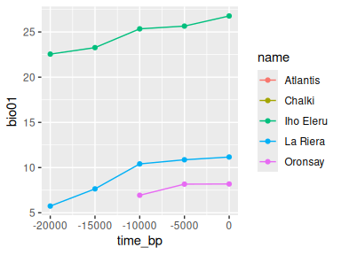

```r
library(ggplot2)
ggplot(data = locations_ts, aes(x = time_bp, y = bio01, group = name)) +
  geom_line(aes(col = name)) +
  geom_point(aes(col = name))
```

As expected, we don’t have data for Atlantis (as it is always underwater), but we also fail to retrieve data for Chalki. This is because `location_series` does not interpolate from nearest neighbours by default (so, it differs from `location_slice` in behaviour). The rationale for this behaviour is that we are interested in whether some locations might end up underwater, and so we do not want to grab climate estimates if they have been submerged. However, in some cases (as for Chalki) it might be necessary to allow for interpolation.

Pretty labels for environmental variables can be generated with `var_labels`:

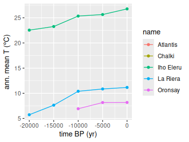

```r
library(ggplot2)
ggplot(data = locations_ts, aes(x = time_bp, y = bio01, group = name)) +
  geom_line(aes(col = name)) +
  geom_point(aes(col = name)) +
  labs(
    y = var_labels("bio01", dataset = "Example", abbreviated = TRUE),
    x = "time BP (yr)"
  )
```

*Note* that these climatic reconstructions were extracted from the `Example` dataset, which is very coarse, so they should not be used to base any real inference about their environmental conditions. But note also that higher resolution is not always better. It is important to consider the appropriate spatial scale that is relevant to the question at hand. Sometimes, it might be necessary to downscale the simulations (see section at the end of this vignette), or in other cases we might want to get estimates to cover an area around the specific location (e.g. if we are comparing to proxies that capture the climatology of a broad area, such as certain sediment cores that capture pollen from the broader region). `location_slice` and `location_series` can provide mean estimates for areas around the location coordinates by setting the `buffer` parameter (see the help pages of those functions for details).

# Get climate for a region

Instead of focussing on specific locations, we might want to look at a whole region. For a given time step, we can extract a slice of climate with

```r
climate_20k <- region_slice(
  time_bp = -20000,
  bio_variables = c("bio01", "bio10", "bio12"),
  dataset = "Example"
)
```

This returns a raster (technically a `SpatRaster` object as defined in the `terra` library, meaning that we can perform all standard `terra` raster operations on this object). To interact with `SpatRaster` objects, you will need to have the library `terra` loaded (otherwise you might get errors as the correct method is not found, e.g. when plotting). `pastclim` automatically loads `terra`, so you should be able to work with `terra` objects without any problem:

```r
climate_20k
```

```
#> class       : SpatRaster
#> dimensions  : 150, 360, 3  (nrow, ncol, nlyr)
#> resolution  : 1, 1  (x, y)
#> extent      : -180, 180, -60, 90  (xmin, xmax, ymin, ymax)
#> coord. ref. : lon/lat WGS 84 (CRS84) (OGC:CRS84)
#> sources     : example_climate_v1.3.0.nc:BIO1
#>               example_climate_v1.3.0.nc:BIO10
#>               example_climate_v1.3.0.nc:BIO12
#> varnames    : bio01 (annual mean temperature)
#>               bio10 (mean temperature of warmest quarter)
#>               bio12 (annual precipitation)
#> names       :           bio01,           bio10,       bio12
#> unit        : degrees Celsius, degrees Celsius, mm per year
#> time (years): -18050
```

and plot these three variables (the layers of the raster):

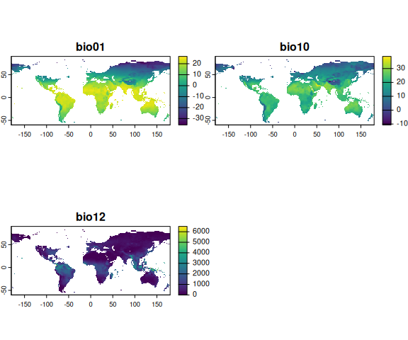

```r
terra::plot(climate_20k)
```

We can add more informative labels with `var_labels`:

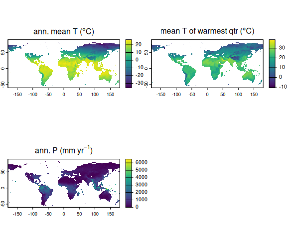

```r
terra::plot(climate_20k,
  main = var_labels(climate_20k, dataset = "Example", abbreviated = TRUE)
)
```

It is possible to also load a time series of rasters with the function `region_series`. In this case, the function returns a `SpatRasterDataset`, with each variable as a sub-dataset:

```r
climate_region <- region_series(
  time_bp = list(min = -15000, max = 0),
  bio_variables = c("bio01", "bio10", "bio12"),
  dataset = "Example"
)
climate_region
```

```
#> class       : SpatRasterDataset
#> subdatasets : 3
#> dimensions  : 150, 360 (nrow, ncol)
#> nlyr        : 4, 4, 4
#> resolution  : 1, 1  (x, y)
#> extent      : -180, 180, -60, 90  (xmin, xmax, ymin, ymax)
#> coord. ref. : lon/lat WGS 84 (CRS84) (OGC:CRS84)
#> source(s)   : example_climate_v1.3.0.nc
#> names       : bio01, bio10, bio12
```

Each of these sub-dataset is a `SpatRaster`, with time steps as layers:

```r
climate_region$bio01
```

```
#> class       : SpatRaster
#> dimensions  : 150, 360, 4  (nrow, ncol, nlyr)
#> resolution  : 1, 1  (x, y)
#> extent      : -180, 180, -60, 90  (xmin, xmax, ymin, ymax)
#> coord. ref. : lon/lat WGS 84 (CRS84) (OGC:CRS84)
#> source      : example_climate_v1.3.0.nc:BIO1
#> varname     : bio01 (annual mean temperature)
#> names       :    bio01_-15000,    bio01_-10000,     bio01_-5000,         bio01_0
#> unit        : degrees Celsius, degrees Celsius, degrees Celsius, degrees Celsius
#> time (years): -13050 to 1950
```

Note that `terra` stores dates in years as AD, not BP. You can inspect the times in years BP with:

```r
time_bp(climate_region)
```

```
#> [1] -15000 -10000  -5000      0
```

We can then plot the time series of a given variable (we relabel the plots to use years bp):

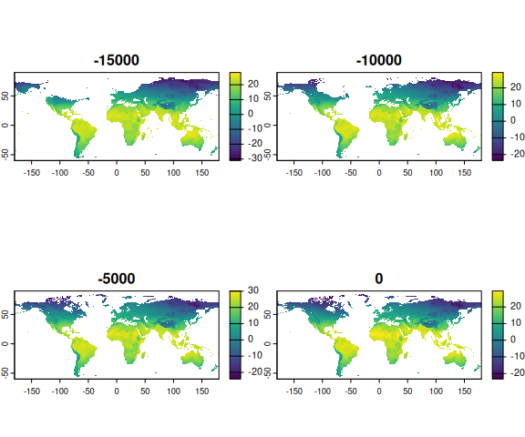

```r
terra::plot(climate_region$bio01, main = time_bp(climate_region))
```

To plot all climate variables for a given time step, we can slice the time series:

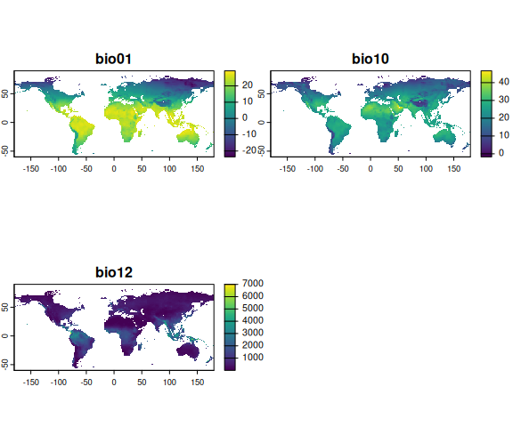

```r
slice_10k <- slice_region_series(climate_region, time_bp = -10000)
terra::plot(slice_10k)
```

Instead of giving a minimum and maximum time step, you can also provide specific time steps to `region_series`. Note that `pastclim` has a function to get a vector of the time steps for a given MIS in a dataset. For example, for MIS 1, we get:

```r
mis1_steps <- get_mis_time_steps(mis = 1, dataset = "Example")
mis1_steps
```

```
#> [1] -10000  -5000      0
```

Which we can then use:

```r
climate_mis1 <- region_series(
  time_bp = mis1_steps,
  bio_variables = c("bio01", "bio10", "bio12"),
  dataset = "Example"
)
climate_mis1
```

```
#> class       : SpatRasterDataset
#> subdatasets : 3
#> dimensions  : 150, 360 (nrow, ncol)
#> nlyr        : 3, 3, 3
#> resolution  : 1, 1  (x, y)
#> extent      : -180, 180, -60, 90  (xmin, xmax, ymin, ymax)
#> coord. ref. : lon/lat WGS 84 (CRS84) (OGC:CRS84)
#> source(s)   : example_climate_v1.3.0.nc
#> names       : bio01, bio10, bio12
```

# Cropping

Often we want to focus a given region. There are a number of preset rectangular extents in `pastclim`:

```r
names(region_extent)
```

```
#> [1] "Africa"    "America"   "Asia"      "Europe"    "Eurasia"   "N_America"
#> [7] "Oceania"   "S_America"
```

We can get the corners of the European extent:

```r
region_extent$Europe
```

```
#> [1] -15  70  33  75
```

And then we can extract climate only for Europe by setting `ext` in `region_slice`:

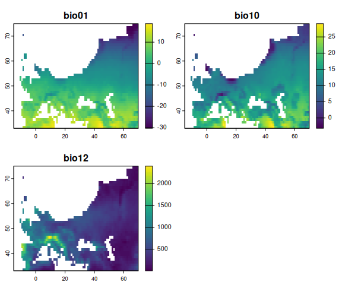

```r
europe_climate_20k <- region_slice(
  time_bp = -20000,
  bio_variables = c("bio01", "bio10", "bio12"),
  dataset = "Example",
  ext = region_extent$Europe
)
terra::plot(europe_climate_20k)
```

As we can see in the plot, cutting Europe using a rectangular shape keeps a portion of Northern Africa in the map. `pastclim` includes a number of pre-generated masks for the main continental masses, stored in the dataset `region_outline` in an `sf::sfc` object. We can get a list with:

```r
names(region_outline)
```

```
#> [1] "Africa"    "Eurasia"   "N_America" "Oceania"   "S_America" "Europe"
```

We can then use the function `crop` within `region_slice` to only keep the area within the desired outline.

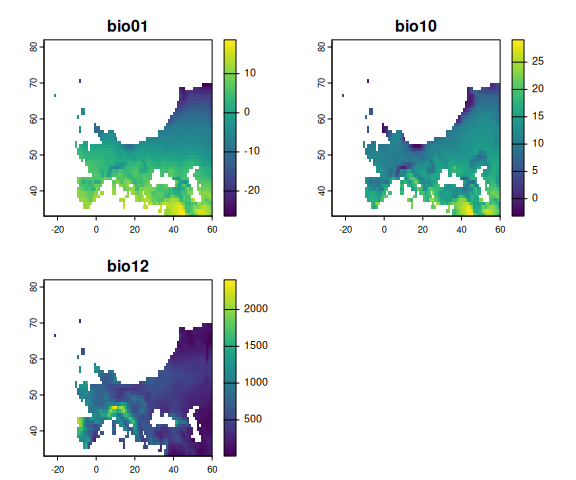

```r
europe_climate_20k <- region_slice(
  time_bp = -20000,
  bio_variables = c("bio01", "bio10", "bio12"),
  dataset = "Example",
  crop = region_outline$Europe
)
terra::plot(europe_climate_20k)
```

We can combine multiple regions together. For example, we can crop to Africa and Eurasia by unioning the two individual outlines:

```r
library(sf)
```

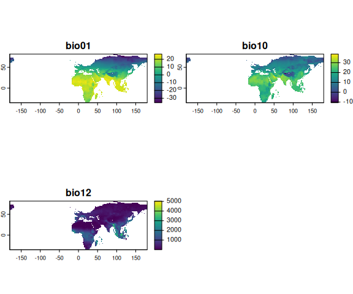

```r
afr_eurasia <- sf::st_union(region_outline$Africa, region_outline$Eurasia)
climate_20k_afr_eurasia <- region_slice(
  time_bp = -20000,
  bio_variables = c("bio01", "bio10", "bio12"),
  dataset = "Example",
  crop = afr_eurasia
)
terra::plot(climate_20k_afr_eurasia)
```

Note that outlines that cross the antimeridian are split into multiple polygons (so that they can be used without projecting the rasters). For Eurasia, we have the eastern end of Siberia on the left hand side of the plot. `continent_outlines_union` provides the same outlines as single polygons (in case you want to use a projection).

You can also use your own custom outline (i.e. a polygon, coded as a `terra::vect` object) as a mask to limit the area covered by the raster. Note that you need to reuse the first vertex as the last vertex, to close the polygon:

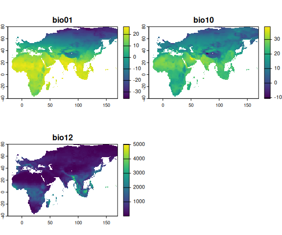

```r
custom_vec <- terra::vect("POLYGON ((0 70, 25 70, 50 80, 170 80, 170 10,
                              119 2.4, 119 0.8, 116 -7.6, 114 -12, 100 -40,
                              -25 -40, -25 64, 0 70))")
climate_20k_custom <- region_slice(
  time_bp = -20000,
  bio_variables = c("bio01", "bio10", "bio12"),
  dataset = "Example",
  crop = custom_vec
)
terra::plot(climate_20k_custom)
```

`region_series` takes the same `ext` and `crop` options as `region_slice` to limit the extent of the climatic reconstructions.

# Working with biomes and ice sheets

The Beyer2020 and Krapp2021 datasets include a categorical variable detailing the extension of biomes.

```r
get_biome_classes("Example")
```

```
#>    id                           category
#> 1   0                       Water bodies
#> 2   1          Tropical evergreen forest
#> 3   2     Tropical semi-deciduous forest
#> 4   3 Tropical deciduous forest/woodland
#> 5   4         Temperate deciduous forest
#> 6   5           Temperate conifer forest
#> 7   6                  Warm mixed forest
#> 8   7                  Cool mixed forest
#> 9   8                Cool conifer forest
#> 10  9                  Cold mixed forest
#> 11 10      Evegreen taiga/montane forest
#> 12 11     Deciduous taiga/montane forest
#> 13 12                   Tropical savanna
#> 14 13      Tropical xerophytic shrubland
#> 15 14     Temperate xerophytic shrubland
#> 16 15     Temperate sclerophyll woodland
#> 17 16      Temperate broadleaved savanna
#> 18 17              Open conifer woodland
#> 19 18                    Boreal parkland
#> 20 19                 Tropical grassland
#> 21 20                Temperate grassland
#> 22 21                             Desert
#> 23 22                      Steppe tundra
#> 24 23                       Shrub tundra
#> 25 24                 Dwarf shrub tundra
#> 26 25             Prostrate shrub tundra
#> 27 26    Cushion forb lichen moss tundra
#> 28 27                             Barren
#> 29 28                           Land ice
```

We can get the biome for 20k years ago and plot it with:

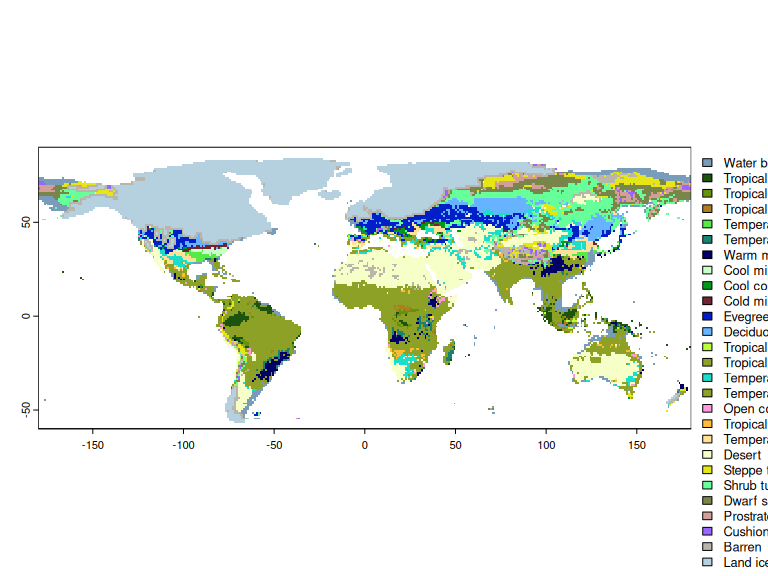

```r
biome_20k <- region_slice(
  time_bp = -20000,
  bio_variables = c("biome"),
  dataset = "Example"
)
plot(biome_20k)
```

Note that the legend is massive. When plotting multiple time slices, it is best to use `legned=FALSE` in the plotting statement to avoid having the legend. If we need to plot the extent of a specific biome, for example the desert, we can simply set the other levels to NA:

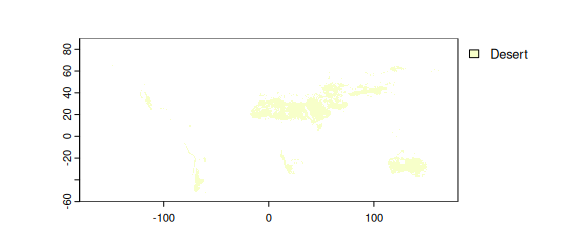

```r
biome_20k$desert <- biome_20k$biome
biome_20k$desert[biome_20k$desert != 21] <- NA
terra::plot(biome_20k$desert)
```

The climate reconstructions do not show areas under permanent ice. Ice sheets are stored as class 28 in the “biome” variable. We can retrieve directly the ice and land (all other biome categories) masks with:

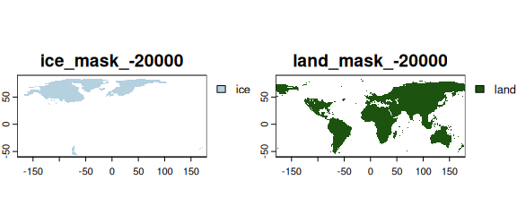

```r
ice_mask <- get_ice_mask(-20000, dataset = "Example")
land_mask <- get_land_mask(-20000, dataset = "Example")
terra::plot(c(ice_mask, land_mask))
```

We can also add the ice sheets to plots of climatic variables. First, we need to turn the ice mask into polygons:

```r
ice_mask_vect <- as.polygons(ice_mask)
```

We can then add the polygons to each layer (i.e. variable) of climate slice with the following code (note that, to add the polygons to every panel of the figure, we need to create a function that is used as an argument for `fun` within `plot`):

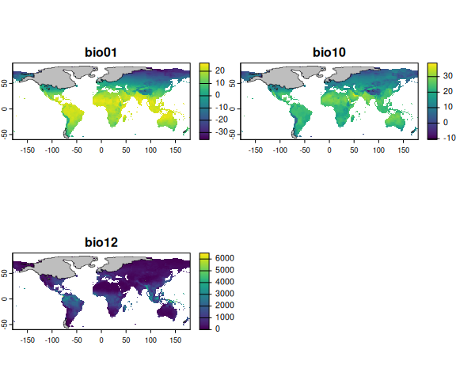

```r
plot(climate_20k,
  fun = function() polys(ice_mask_vect, col = "gray", lwd = 0.5)
)
```

In some other cases, we have multiple time points of the same variable and we want to see how the ice sheets change:

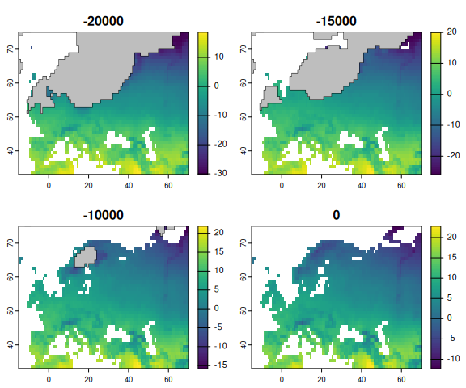

```r
europe_climate <- region_series(
  time_bp = c(-20000, -15000, -10000, 0),
  bio_variables = c("bio01"),
  dataset = "Example",
  ext = region_extent$Europe
)
ice_masks <- get_ice_mask(c(-20000, -15000, -10000, 0),
  dataset = "Example"
)
ice_poly_list <- lapply(ice_masks, as.polygons)
plot(europe_climate$bio01,
  main = time_bp(europe_climate),
  fun = function(i) {
    polys(ice_poly_list[[i]],
      col = "gray",
      lwd = 0.5
    )
  }
)
```

Note that to add the ice sheets in this instance, we build a function that takes a single parameter *i* which is the index of the image (i.e. *i* from 1 to 4 in the plot above) and use it to subset the list of ice outlines.

Sometimes it is interesting to measure the distance from the coastline (e.g. when modelling species that rely on brackish water, or to determine the distance from marine resources in archaeology). In `pastclim`, we can use use `distance_from_sea`, which accounts for sea level change based on the landmask:

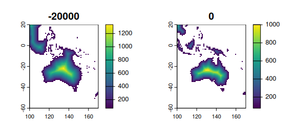

```r
distances_sea <- distance_from_sea(time_bp = c(-20000, 0), dataset = "Example")
distances_sea_australia <- crop(distances_sea, terra::ext(100, 170, -60, 20))
plot(distances_sea_australia, main = time_bp(distances_sea_australia))
```

# Adding locations to region plots

To plot locations on region plots, we first need to create a `SpatVector` object from the dataframe of metadata, specifying the names of the columns with the x and y coordinates:

```r
locations_vect <- vect(locations, geom = c("longitude", "latitude"))
locations_vect
```

```
#>  class       : SpatVector
#>  geometry    : points
#>  dimensions  : 5, 2  (geometries, attributes)
#>  extent      : -24, 27, 7, 56  (xmin, xmax, ymin, ymax)
#>  coord. ref. :
#>  names       :      name    time_bp
#>  type        :     <chr>      <num>
#>  values      : Iho Eleru  -1.12e+04
#>                 La Riera -1.874e+04
#>                   Chalki -1.023e+04
```

We can then add it to a climate slice with the following code (note that, to add the points to every panel of the figure, we need to create a function that is used as an argument for `fun` within `plot`):

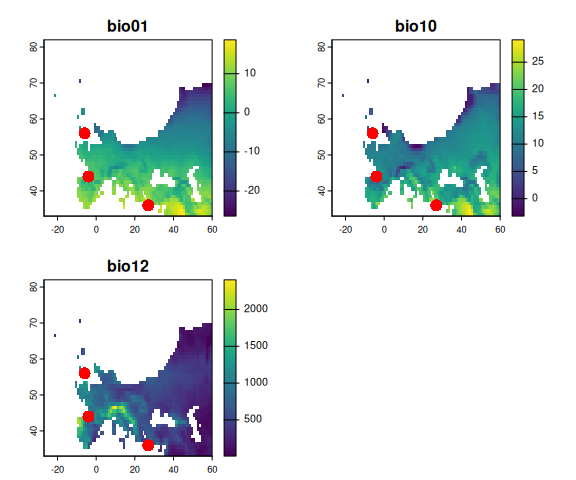

```r
plot(europe_climate_20k,
  fun = function() points(locations_vect, col = "red", cex = 2)
)
```

Only the points within the extent of the region will be plotted (so, in this case, only the European locations).

We can combine ice sheets and locations in a single plot:

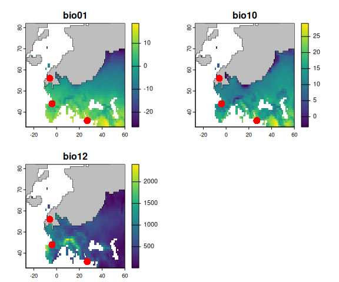

```r
plot(europe_climate_20k,
  fun = function() {
    polys(ice_mask_vect, col = "gray", lwd = 0.5)
    points(locations_vect, col = "red", cex = 2)
  }
)
```

# Set the samples within the background

In many studies, we want to set the environmental conditions at a given set of location within the background for that time period. Let us start by visualising the background for the time step of interest with a PCA:

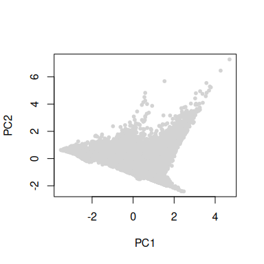

```r
bio_vars <- c("bio01", "bio10", "bio12")
climate_10k <- region_slice(-10000,
  bio_variables = bio_vars,
  dataset = "Example"
)
climate_values_10k <- df_from_region_slice(climate_10k)
climate_10k_pca <- prcomp(climate_values_10k[, bio_vars],
  scale = TRUE, center = TRUE
)
plot(climate_10k_pca$x[, 2] ~ climate_10k_pca$x[, 1],
  pch = 20, col = "lightgray",
  xlab = "PC1", ylab = "PC2"
)
```

We can now get the climatic conditions for the locations at this time step and compute the PCA scores based on the axes we defined on the background:

```r
locations_10k <- data.frame(
  longitude = c(0, 90, 20, 5), latitude = c(20, 45, 50, 47),
  time_bp = c(-9932, -9753, -10084, -10249)
)
climate_loc_10k <- location_slice(
  x = locations_10k[, c("longitude", "latitude")],
  time_bp = locations_10k$time_bp, bio_variables = bio_vars,
  dataset = "Example"
)
locations_10k_pca_scores <- predict(climate_10k_pca,
  newdata = climate_loc_10k[, bio_vars]
)
```

And now we can plot the points on top of the background

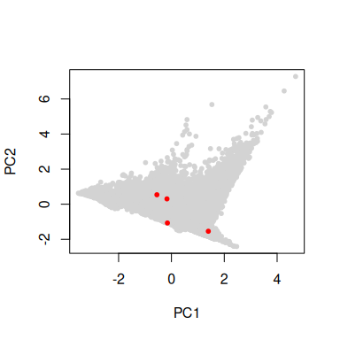

```r
plot(climate_10k_pca$x[, 2] ~ climate_10k_pca$x[, 1],
  pch = 20, col = "lightgray",
  xlab = "PC1", ylab = "PC2"
)
points(locations_10k_pca_scores, pch = 20, col = "red")
```

If we want to pool the background from multiple time steps, we can simple use `region_series` to get a series, and then transform it into a data frame with `df_from_region_series`.

# Random sampling of background

In some instances (e.g. when the underlying raster is too large to handle), it might be desirable to sample the background instead of using all values. If we are interested in a single time step, we can simply generate the raster for the time slice of interest, and use `sample_region_slice`:

```r
climate_20k <- region_slice(
  time_bp = -20000,
  bio_variables = c("bio01", "bio10"),
  dataset = "Example"
)
this_sample <- sample_region_slice(climate_20k, size = 100)
head(this_sample)
```

```
#>    cell      x     y     bio01    bio10
#> 1 40630  129.5 -22.5  20.21618 26.69681
#> 2  5710  129.5  74.5 -30.61778 12.59825
#> 3 22982  121.5  26.5  10.00819 23.02845
#> 4 21312 -108.5  30.5  10.81128 19.49276
#> 5 29279  -61.5   8.5  21.55644 23.02785
#> 6 24652   -8.5  21.5  22.22025 28.94772
```

```r
climate_ts <- region_series(
  time_bp = c(-20000, -10000),
  bio_variables = c("bio01", "bio10", "bio12"),
  dataset = "Example",
  ext = terra::ext(region_extent$Europe)
)
sampled_climate <- sample_region_series(climate_ts, size = c(3, 5))
sampled_climate
```

```
#>          cell    x    y     bio01     bio10    bio12 time_bp
#> -20000.1 2584 18.5 44.5  4.644144 13.054743 953.5013  -20000
#> -20000.2 2272 46.5 48.5  1.478668  9.483013 309.4925  -20000
#> -20000.3 2802 66.5 42.5  7.519086 20.927559 177.0821  -20000
#> -10000.1 1917 31.5 52.5  5.340712 19.035126 630.0278  -10000
#> -10000.2 2309 -1.5 47.5 10.826094 18.593153 746.7918  -10000
#> -10000.3 2082 26.5 50.5  6.921721 19.466261 522.0778  -10000
#> -10000.4 3388 57.5 35.5 15.919691 30.962671 148.1532  -10000
#> -10000.5 1562 16.5 56.5  5.345322 14.230188 512.9127  -10000
```

We could then use these data to build a PCA.

# Downscaling

`pastclim` does not contain built-in code to change the spatial resolution of the climatic reconstructions, but it is possible to downscale the data by using the relevant function from the `terra` package.

At first we will need to extract a region and time of choice, in this case Europe 10,000 years ago

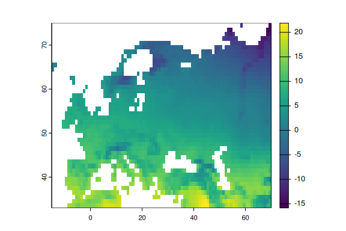

```r
europe_10k <- region_slice(
  dataset = "Example",
  bio_variables = c("bio01"),
  time_bp = -10000, ext = region_extent$Europe
)
terra::plot(europe_10k)
```

We can then downscale using the `disagg()` function from the `terra` package, requiring an aggregation factor expressed as number of cells in each direction (horizontally, vertically, and, if needed, over layers). In the example below we used 25 both horizontally and vertically, using bilinear interpolation.

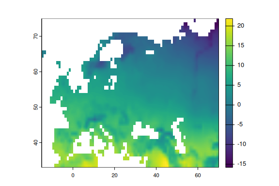

```r
europe_ds <- terra::disagg(europe_10k, fact = 25, method = "bilinear")
terra::plot(europe_ds)
```

Note that, whilst we have smoothed the climate, the land mask has not changed, and thus it still has very blocky edges.